# Factsheet Vlaamse Arbeidsmarkt

Published

March 30, 2026

[figure not shown]

[figure not shown]

# Vlaamse Arbeidsmarkt

## Stand van zaken 2024

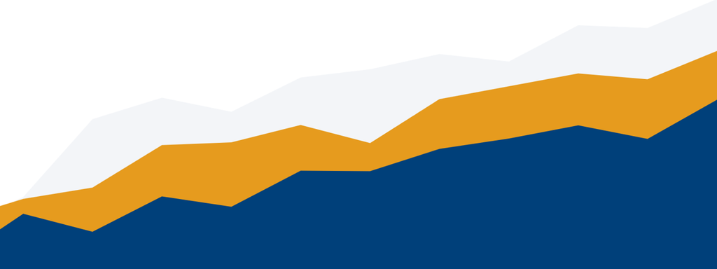

76,9% Werkzaamheidsgraad +0,1 ppt vs. 2023

3,8% Werkloosheidsgraad +0,5 ppt vs. 2023

214.106 Werkzoekenden zonder werk +3,7% op jaarbasis

57.959 Openstaande vacatures maart 2025

In 2024 bleef de **werkzaamheidsgraad** van het Vlaamse Gewest relatief stabiel op 76,9%, vrijwel gelijk aan het niveau van een jaar eerder (76,8%). De **werkloosheidsgraad** nam echter licht toe tot 3,8% — het hoogste peil in drie jaar. Op vlak van tewerkstelling is de jaargroei licht negatief, waarbij de publieke sector als stabiele motor fungeert terwijl de industrie terrein verliest. Op de vacaturemarkt daalt het aantal ontvangen vacatures verder, al blijven er nog steeds duizenden moeilijk in te vullen jobs.

## Werkzaamheid

De werkzaamheidsgraad voor de bevolking van 20 tot 64 jaar sluit 2024 af op **76,9%**. Hoewel dit vrijwel stabiel is ten opzichte van 2023, is er per kwartaal een lichte stijging merkbaar (+0,3 ppt). Het EU-2030-doel van 80% blijft in zicht maar vraagt om verdere inspanningen.

**Opvallende evoluties:**

- **55-plussers** kennen de sterkste stijging (+1,6 ppt), maar noteren nog steeds 62,4% — ruim onder het gemiddelde
- **Kortgeschoolden** zetten voor het tweede jaar op rij een positieve jaargroei neer (+1,1 ppt) en bereiken 53,7%
- **20–24-jarigen** ondervinden een lichte daling (−0,8 ppt)

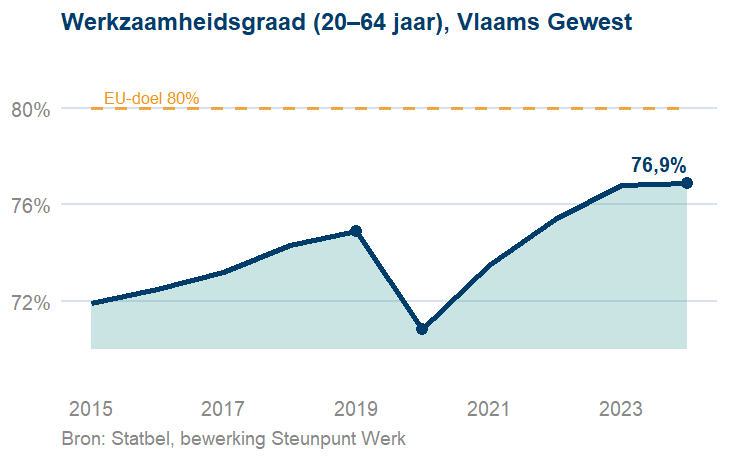

## Werkloosheid

De werkloosheidsgraad stijgt in het vierde kwartaal van 2024 tot **3,8%** (trendniveau). Dit is een toename van 0,5 procentpunt op jaarbasis en het hoogste niveau in drie jaar.

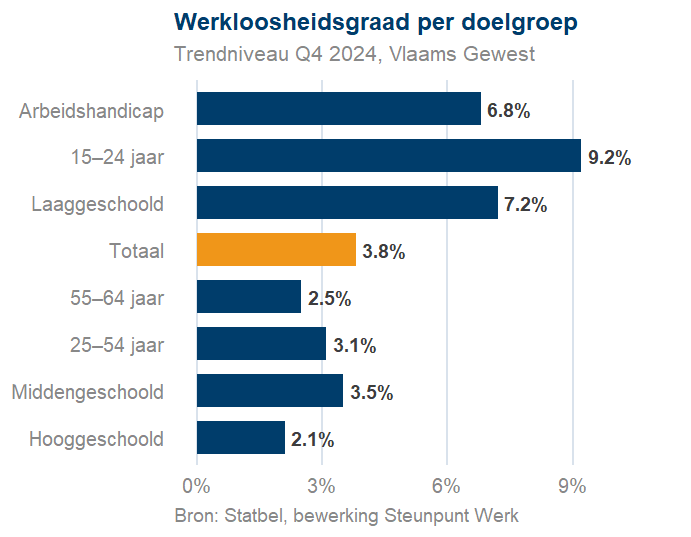

Langdurige werkloosheid Het aantal werkzoekenden dat **1 tot 2 jaar werkloos** is, nam met 25,0% toe — de sterkste stijging van alle subgroepen.

## Tewerkstelling & sectoren

De loontrekkende tewerkstelling daalt in Q4 2024 licht (−0,1% op jaarbasis). Uitgedrukt in **voltijds equivalenten** is de daling sterker: −0,4%.

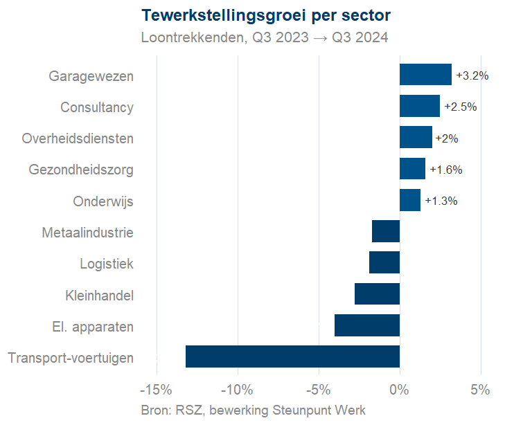

## Vacatures & krapte

Het aantal bij VDAB gemelde vacatures daalt verder. Tussen april 2024 en maart 2025 werden **292.902 vacatures** ontvangen — een daling van 7,7% op jaarbasis. Toch staan er nog steeds **57.959 vacatures open**.

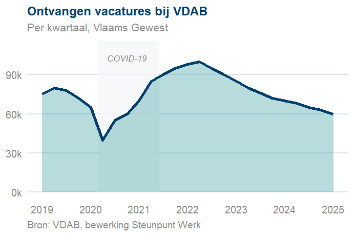

**Positieve uitzonderingen:** transport & logistiek (+0,6%) en openbare besturen (+10,5%) meldden meer vacatures.

Ruben De Smet · Ines Penders · Boie Neefs · Anneleen Huyghe · Sarah Vansteenkiste · *Steunpunt Werk*

© Steunpunt Werk  
Vlamingenstraat 83 bus 3552 — 3000 Leuven  
steunpuntwerk@kuleuven.be · www.steunpuntwerk.be

[figure not shown]

[figure not shown]

01